# Week10 PREDICTING BOX OFFICE REVENUE

Kyu Cho

August 19, 2015

# Introduction

Each year, box offices at movie theaters collect billions of dollars in revenue in the United States alone. In this problem, we seek to determine whether or not we can predict box office revenue based on different variables related to a movie.

# Variables

In this problem, we’ll use a dataset of 334 movies that were produced from 1953 to 2015. The dataset Movies.csv includes the following 24 variables:

- Name = the name of the movie
- Year = the year the movie was produced
- Rated = the rating given to the movie by the MPAA
- Runtime = the duration of the movie in minutes
- Action = binary variable that takes value 1 if the movie is an action movie, 0 otherwise
- Adventure, Crime, Drama, Thriller, Fantasy, Horror, Sci.Fi, Comedy, Family, Mystery, Romance, Animation, Music, History, Documentary are all defined like Action
- Wins = number of awards won by the movie
- Nominations = number of awards the movie was nominated for
- Production.Budget = the natural logarithm of the production budget in dollars
- Worldwide = the natural logarithm of the worldwide revenue in dollars

## PROBLEM 1 - LOADING THE DATA

```r
library(caTools)
setwd("D:/Google Drive/College/4-The Analytics Edge/data10")
Movies = read.csv('Movies.csv')
str(Movies)
```

```
## 'data.frame':    334 obs. of  24 variables:
##  $ Name             : Factor w/ 334 levels "2 Fast 2 Furious",..: 28 32 31 29 30 247 248 4 5 6 ...
##  $ Year             : int  1989 1992 1995 1997 2005 2008 2012 2002 2006 2014 ...
##  $ Rated            : Factor w/ 6 levels "Approved","G",..: 5 5 5 5 5 3 5 6 6 6 ...
##  $ Runtime          : int  126 126 121 125 140 152 165 113 117 102 ...
##  $ Action           : int  1 1 1 1 1 1 1 0 1 1 ...
##  $ Adventure        : int  1 0 1 0 1 0 0 0 0 0 ...
##  $ Crime            : int  0 0 0 0 0 1 0 0 0 0 ...
##  $ Drama            : int  0 0 0 0 0 1 0 0 0 1 ...
##  $ Thriller         : int  0 0 0 0 0 0 1 0 0 0 ...
##  $ Fantasy          : int  0 0 1 0 0 0 0 0 1 1 ...
##  $ Horror           : int  0 0 0 0 0 0 0 1 0 0 ...
##  $ Sci.Fi           : int  0 0 0 0 0 0 0 0 0 0 ...
##  $ Comedy           : int  0 0 0 0 0 0 0 0 0 0 ...
##  $ Family           : int  0 0 0 0 0 0 0 0 0 0 ...
##  $ Mystery          : int  0 0 0 0 0 0 0 0 0 0 ...
##  $ Romance          : int  0 0 0 0 0 0 0 0 0 0 ...
##  $ Animation        : int  0 0 0 0 0 0 0 0 0 0 ...
##  $ Music            : int  0 0 0 0 0 0 0 0 0 0 ...
##  $ History          : int  0 0 0 0 0 0 0 0 0 0 ...
##  $ Documentary      : int  0 0 0 0 0 0 0 0 0 0 ...
##  $ Wins             : int  10 2 9 5 15 134 43 10 12 0 ...
##  $ Nominations      : int  21 16 20 20 49 106 83 25 30 6 ...
##  $ Production.Budget: num  18.1 18.9 19.1 19.2 19.1 ...
##  $ Worldwide        : num  20.6 20.1 20.3 19.9 20 ...
```

Create a training set that consists of movies released before 2010 and a testing set that consists of movies released in 2010 and after.

```r
train = subset(Movies, Year < 2010)
test = subset(Movies, Year >= 2010)
```

## PROBLEM 2 - METHOD OF SPLITTING THE DATA

Q : In this class, we have frequently used the sample.split function to randomly split our data. Why do we use a different approach here? Check all that apply. A : The sample.split function is typically used to split data with a categorical dependent variable, and we have a continuous dependent variable. Also, We don’t want to randomly split our data here, so the sample.split function is not appropriate.

## PROBLEM 3 - A LINEAR REGRESSION MODE

In your linear regression model, which of the independent variables are significant at the p=0.05 level (at least one star)? For factor variables, consider the variable significant if at least one level is significant. Select all that apply.

```r
model.LM = lm(Worldwide~.-Name-Year, data=train)
summary(model.LM)
```

```
##
## Call:
## lm(formula = Worldwide ~ . - Name - Year, data = train)
##
## Residuals:
##     Min      1Q  Median      3Q     Max
## -1.8311 -0.3893  0.0809  0.3906  1.6326
##
## Coefficients:
##                     Estimate Std. Error t value Pr(>|t|)
## (Intercept)       15.9976766  1.1580192  13.815  < 2e-16 ***
## RatedG             0.4102319  0.7041759   0.583 0.560774
## RatedN/A           0.5562304  0.7322003   0.760 0.448258
## RatedPG            0.7090507  0.6892058   1.029 0.304696
## RatedPG-13         0.6027509  0.7107462   0.848 0.397322
## RatedR             0.4127760  0.7210913   0.572 0.567608
## Runtime            0.0097079  0.0032359   3.000 0.003007 **
## Action             0.0172144  0.1333332   0.129 0.897389
## Adventure         -0.2232011  0.1283551  -1.739 0.083432 .
## Crime             -0.3315595  0.1473878  -2.250 0.025457 *
## Drama             -0.2097674  0.1881216  -1.115 0.266029
## Thriller          -0.1067814  0.1364400  -0.783 0.434682
## Fantasy            0.1634927  0.1406340   1.163 0.246264
## Horror            -0.6173923  0.2056864  -3.002 0.002993 **
## Sci.Fi            -0.0147251  0.1353512  -0.109 0.913466
## Comedy            -0.1431461  0.1611241  -0.888 0.375276
## Family            -0.3206547  0.1780467  -1.801 0.073067 .
## Mystery            0.1454495  0.1837735   0.791 0.429520
## Romance           -0.0449227  0.2063239  -0.218 0.827840
## Animation          0.6116779  0.2085349   2.933 0.003706 **
## Music             -0.1531571  0.6860353  -0.223 0.823546
## History           -1.3823299  0.6876694  -2.010 0.045624 *
## Documentary       -0.4480795  0.4830499  -0.928 0.354620
## Wins               0.0003704  0.0039940   0.093 0.926186
## Nominations        0.0159878  0.0043745   3.655 0.000321 ***
## Production.Budget  0.1104362  0.0550254   2.007 0.045962 *
## ---
## Signif. codes:  0 '***' 0.001 '**' 0.01 '*' 0.05 '.' 0.1 ' ' 1
##
## Residual standard error: 0.6431 on 222 degrees of freedom
## Multiple R-squared:  0.5413, Adjusted R-squared:  0.4896
## F-statistic: 10.48 on 25 and 222 DF,  p-value: < 2.2e-16
```

## PROBLEM 4 - CHECKING FOR SIGNIFICANCE

In your linear regression model, which of the independent variables are significant at the p=0.05 level (at least one star)? For factor variables, consider the variable significant if at least one level is significant. Select all that apply.

```r
# extract p-factors
model.summary = summary(Model.LM)$coefficients

#independent variables significant at the p=0.05 level
sort(model.summary[,4]<0.05)
```

```
##            RatedG          RatedN/A           RatedPG        RatedPG-13
##             FALSE             FALSE             FALSE             FALSE
##            RatedR            Action         Adventure             Drama
##             FALSE             FALSE             FALSE             FALSE
##          Thriller           Fantasy            Sci.Fi            Comedy
##             FALSE             FALSE             FALSE             FALSE
##            Family           Mystery           Romance             Music
##             FALSE             FALSE             FALSE             FALSE
##       Documentary              Wins       (Intercept)           Runtime
##             FALSE             FALSE              TRUE              TRUE
##             Crime            Horror         Animation           History
##              TRUE              TRUE              TRUE              TRUE
##       Nominations Production.Budget
##              TRUE              TRUE
```

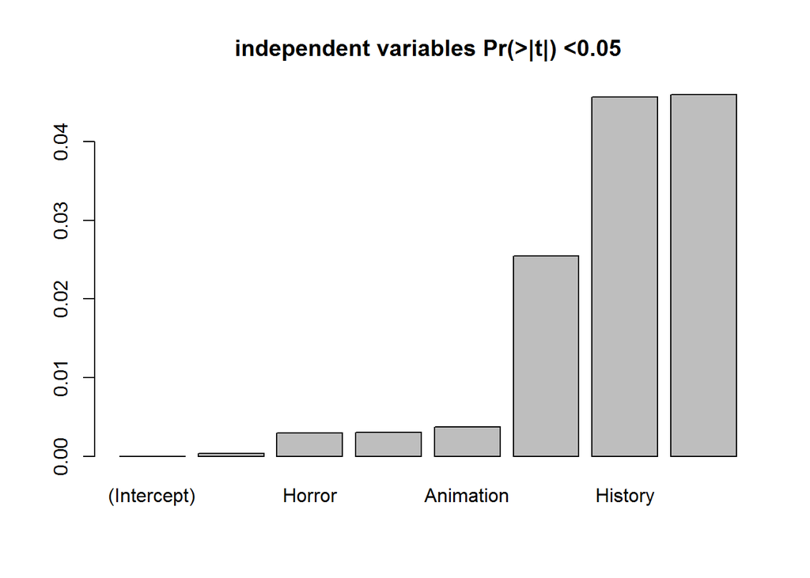

```r
barplot(sort(model.summary[model.summary[,4]<0.05, 4]), main="independent variables Pr(>|t|) <0.05")
```

## PROBLEM 5 - CORRELATIONS

What is the correlation between Worldwide and Production.Budget in the training set?

```r
cor(train$Worldwide, train$Production.Budget)
```

```
## [1] 0.4947683
```

Q : Given this value, should Production.Budget be included in the model? A : Yes, it has high predictive value since the independent variable is correlated with a dependent variable

## PROBLEM 6 - AN UPDATED MODEL

Create a new linear regression model on the training set with only the significant variables you found in Problem 4 as the independent variables. Going forward, we will only consider this linear regression model.

What is the model’s R-squared? (Please report the “Multiple R-squared” value in the output.)

```r
model.LM2 = lm(Worldwide~Runtime+Crime+Horror+Animation+History+Nominations+Production.Budget, data=train)
summary(model.LM2)
```

```
##
## Call:
## lm(formula = Worldwide ~ Runtime + Crime + Horror + Animation +
##     History + Nominations + Production.Budget, data = train)
##
## Residuals:
##      Min       1Q   Median       3Q      Max
## -1.87336 -0.36913  0.07701  0.37701  1.93620
##
## Coefficients:
##                    Estimate Std. Error t value Pr(>|t|)
## (Intercept)       15.531741   0.803224  19.337  < 2e-16 ***
## Runtime            0.010095   0.002634   3.833 0.000162 ***
## Crime             -0.293315   0.120701  -2.430 0.015829 *
## Horror            -0.427419   0.141596  -3.019 0.002814 **
## Animation          0.465257   0.166530   2.794 0.005629 **
## History           -1.556980   0.650418  -2.394 0.017443 *
## Nominations        0.017313   0.003010   5.751 2.68e-08 ***
## Production.Budget  0.152527   0.046708   3.266 0.001252 **
## ---
## Signif. codes:  0 '***' 0.001 '**' 0.01 '*' 0.05 '.' 0.1 ' ' 1
##
## Residual standard error: 0.6426 on 240 degrees of freedom
## Multiple R-squared:  0.5048, Adjusted R-squared:  0.4904
## F-statistic: 34.95 on 7 and 240 DF,  p-value: < 2.2e-16
```

## PROBLEM 7 - UNDERSTANDING COEFFICIENTS

In the model from Problem 6, what is the coefficient for Animation in the linear regression?

```r
model.LM2$coefficients
```

```
##       (Intercept)           Runtime             Crime            Horror
##       15.53174087        0.01009520       -0.29331525       -0.42741889
##         Animation           History       Nominations Production.Budget
##        0.46525656       -1.55698032        0.01731273        0.15252739
```

Q : The coefficient for Runtime is 0.010095. What is the interpretation of this coefficient? A : For an additional minute of Runtime, the prediction for the variable Worldwide increases by approximately 0.01 units

## PROBLEM 8 - PREDICTIONS ON THE TEST SET

Make predictions on the test set using your linear regression model. What is the Sum of Squared Errors (SSE) on the test set?

```r
pred.LM2 = predict(model.LM2, newdata = test)

# SSE
SSE = sum((pred.LM2 - test$Worldwide)^2)

#the Total Sum of Squares (SST) on the test set
SST = sum((mean(test$Worldwide) - test$Worldwide)^2)

#R-squared on the test set
Rsquared = 1-SSE/SST

print(paste("SSE=", SSE, "SST=", SST, "Rsquared=", Rsquared))
```

```
## [1] "SSE= 25.0005997807204 SST= 60.3587341024956 Rsquared= 0.585799799275666"
```

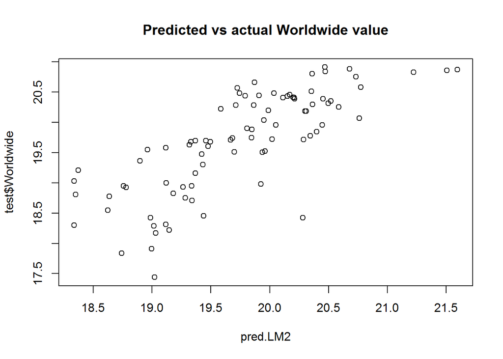

```r
#plot the predicted Worldwide value vs the actual value
plot(pred.LM2, test$Worldwide, main="Predicted vs actual Worldwide value")
```

## PROBLEM 9 - UNDERSTANDING THE MODEL

Q : True or False: Our linear regression model suffers from overfitting. A : False. The R-squared value on the test set is higher than on the training set, so there is no overfitting going on here.

## PROBLEM 10 - A CLASSIFICATION PROBLEM

Let’s turn this problem into a multi-class classification problem by creating a new dependent variable. Our new dependent variable will take three different values: “Excellent”, “Average”, and “Poor” for films with Worldwide revenue in the top quartile, middle 50%, and bottom quartile, respectively. Create this variable, called “Performance”, in your dataset Movies by running the following line in your R console:

Movies$Performance = factor(ifelse(Movies$Worldwide > quantile(Movies$Worldwide, .75), "Excellent", ifelse(Movies$Worldwide > quantile(Movies$Worldwide, .25), “Average”, “Poor”)))

```r
Movies$Performance = factor(ifelse(Movies$Worldwide > quantile(Movies$Worldwide, .75), "Excellent", ifelse(Movies$Worldwide > quantile(Movies$Worldwide, .25), "Average", "Poor")))
table(Movies$Performance)
```

```
##
##   Average Excellent      Poor
##       166        84        84
```

Now, remove the original dependent variable “Worldwide” from your dataset with the command: Movies$Worldwide = NULL

```r
Movies$Worldwide = NULL
```

Then, randomly split Movies into a training set, containing 70% of the observations, and a testing set, containing 30% of the observations. This time, you should use the sample.split function with the dependent variable “Performance”. Right before calling the sample.split function, set the seed to 15071.

```r
library(caTools)
set.seed(15071)
split = sample.split(Movies$Performance, SplitRatio=0.7)
table(split)
```

```
## split
## FALSE  TRUE
##   100   234
```

```r
train = Movies[split==TRUE,]
test = Movies[split==FALSE,]
```

## PROBLEM 11 - A CART MODEL

Build a CART model to predict “Performance” using all of the other variables except for “Name and”Year" to build the model.  
(Unless you have re-ordered your columns, an easy way to do this is to send MoviesTrain[ , 3:ncol(MoviesTrain)] as the data argument, assuming your new training set is called “MoviesTrain.”)  
Remember that to predict a multi-class dependent variable, you can use the rpart function in the same way as for a binary classification problem. Just use the default parameter settings (don’t set a value for minbucket or cp).

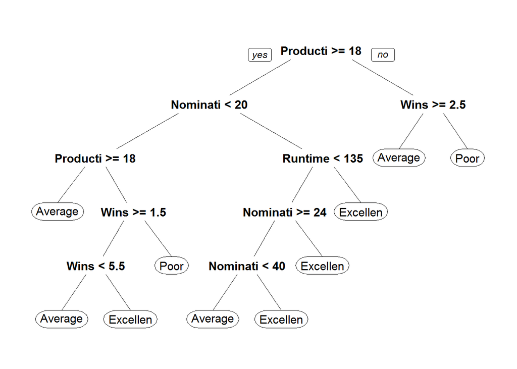

```r
library(rpart)
library(rpart.plot)
model.CART = rpart(Performance ~ ., data=train[ , 3:ncol(train)] )
prp(model.CART)
```

Q : The CART model you just built predicts only two possible outcomes for a movie with Production.Budget less than 18. Which outcome does it never predict for these low-budget films?  
A : Excellent

## PROBLEM 12 - TRAINING SET ACCURACY

Make predictions on the training set, and then create a confusion matrix. What is the overall accuracy of the model?

```r
pred.CART = predict(model.CART, newdata=train, type="class")
tbl.CART = table(train$Performance, pred.CART)
tbl.CART
```

```
##            pred.CART
##             Average Excellent Poor
##   Average        96         9   11
##   Excellent      17        41    1
##   Poor           11         2   46
```

```r
accuracy.CART = (96+41+46)/sum(tbl.CART)
accuracy.CART
```

```
## [1] 0.7820513
```

## PROBLEM 13 - A BASELINE MODEL

What is the accuracy on the training set of a baseline model that predicts the most frequent outcome (Average) for all observations?

```r
tbl.base = table(train$Performance)
tbl.base
```

```
##
##   Average Excellent      Poor
##       116        59        59
```

```r
accuracy.base =  116/sum(tbl.base)
accuracy.base
```

```
## [1] 0.4957265
```

## PROBLEM 14 - TESTING SET ACCURACY

Make predictions on the testing set, and then create a confusion matrix. What is the overall accuracy of the model on the testing set?

```r
pred2.CART = predict(model.CART, newdata=test, type="class")
tbl2.CART = table(test$Performance, pred2.CART)
tbl2.CART
```

```
##            pred2.CART
##             Average Excellent Poor
##   Average        36         8    6
##   Excellent       9        16    0
##   Poor            8         1   16
```

```r
accuracy2.CART = (36+16+16)/sum(tbl2.CART)
accuracy2.CART
```

```
## [1] 0.68
```

## PROBLEM 15 - BASELINE ACCURACY ON TESTING SET

What is the accuracy on the testing set of a baseline model that predicts the most frequent outcome (Average) for all observations?

```r
tbl2.base = table(test$Performance)
tbl2.base
```

```
##
##   Average Excellent      Poor
##        50        25        25
```

```r
accuracy2.base =  (50)/sum(tbl2.base)
accuracy2.base
```

```
## [1] 0.5
```